# index

**Analysis of League of Legends Games**

Matthew Huang, Isaac Chen, Ingrette Wang

**Contribution Checkpoint**

A: Project idea - 5%

B: Dataset Curation and Preprocessing - 10%

C: Data Exploration and Summary Statistics - 10%

D: ML Algorithm Design/Development - 25%

E: ML Algorithm Training and Test Data Analysis - 20%

F: Visualization, Result Analysis, Conclusion - 15%

G: Final Tutorial Report Creation - 10%

H: Additional (not listed above, if any) - 5%

Member 1: Matthew Huang, Contribution: 100%.

Member 2: Isaac Chen, Contribution: 85% (did not contribute to H and G).

Member 3: Ingrette Wang Contribution: 85% (did not contribute to H and C).

Released in October 2009, League of Legends has solidified itself as one of the most popular played video games for the past decade. At its core, League of Legends is a 5v5 MOBA (multiplayer online battle arena) game where two teams of players face off against one another, and race to see who can destroy the other team’s base first. Although the game has evolved over its lifespan, the core gameplay of teams trying to create an advantage over the team has stayed consistent. Being a complex game with many factors influencing a game’s state and outcome, are there any specific factors that can predict the outcome of a game? These are some questions that we aim to answer in this tutorial.

**What features make up a game of League of Legends?**

The game takes place on a map with a main base (nexus), with three main lanes expanding out from the main base. Each lane contains an inhibitor, and three towers that protect enemies from entering the main base. The main objective of the game is to destroy the enemies main base by marching down one(or multiple) lanes, destroying towers and inhibitors along the way. Throughout the game, players from both teams are able to unlock and upgrade their champions’ abilities as they level up, which can be achieved through a couple of different ways. Players can level up by defeating enemy champions in combat, granting them experience, as well as gold, which can be used to buy items in an item shop that increases a player’s stats (attack damage, magic damage, movement speed, health, to name a few), which creates an advantage for that player. Another way that players can level up is through killing lane minions, which are NPC’s (non-playable characters) that spawn every 30 seconds and grant gold and experience upon death.

More in-depth information about the game can be found here  
https://www.leagueoflegends.com/en-us/how-to-play/  
https://en.wikipedia.org/wiki/League_of_Legends

In this tutorial, we will be analyzing how multiple factors such as gold difference, starting team side (red or blue), and more factors from around 10,000 Diamond ranked games, can predict a game’s outcome. By analyzing this data, we hope to better explore the different facets that contribute toward game results, and gain insights into strategies and patterns that lead to success in the competitive scene.

**Data Curration**

Our data was obtained through the Riot Games API, and was obtained through an uploader who classified the data as public domain. The format of the original data is contained in a csv file that contains 9,879 entries.  
Because the raw data is already in numerical format so there is no need to convert our data to integers. However, we will be deleting some uncessary columns such as (blueFirstBlood, redFirstBlood, gameId, blueEliteMonsters, and redEliteMonsters) Based off our own experiences that we have from playing the game, these data values don't provide much value when it comes to analysis of game outcomes. The advantage earned from getting first blood is only 100 gold, which is pretty negligible in the grand scheme of the game. The number of elite monsters killed is also minor, as only one elite monster spawns within the first ten minutes of the game, and the buff it provides isn't enough to determine a game's outcome.  
Here are some basic python packages that we will use in this project.

```python
import pandas as pd
import matplotlib.pyplot as plt
from scipy import stats
import seaborn as sns
from sklearn.model_selection import train_test_split, cross_val_score, StratifiedKFold
from sklearn.preprocessing import StandardScaler
from sklearn.naive_bayes import GaussianNB
from sklearn.tree import DecisionTreeClassifier
from sklearn.linear_model import LogisticRegression
from sklearn.metrics import accuracy_score, classification_report
from sklearn.metrics import recall_score, precision_score
```

Importing the dataset into a dataframe.

```python
df = pd.read_csv('high_diamond_ranked_10min.csv')
df.head(10)
```

|  | gameId | blueWins | blueWardsPlaced | blueWardsDestroyed | blueFirstBlood | blueKills | blueDeaths | blueAssists | blueEliteMonsters | blueDragons | ... | redTowersDestroyed | redTotalGold | redAvgLevel | redTotalExperience | redTotalMinionsKilled | redTotalJungleMinionsKilled | redGoldDiff | redExperienceDiff | redCSPerMin | redGoldPerMin |
| --- | --- | --- | --- | --- | --- | --- | --- | --- | --- | --- | --- | --- | --- | --- | --- | --- | --- | --- | --- | --- | --- |
| 0 | 4519157822 | 0 | 28 | 2 | 1 | 9 | 6 | 11 | 0 | 0 | ... | 0 | 16567 | 6.8 | 17047 | 197 | 55 | -643 | 8 | 19.7 | 1656.7 |
| 1 | 4523371949 | 0 | 12 | 1 | 0 | 5 | 5 | 5 | 0 | 0 | ... | 1 | 17620 | 6.8 | 17438 | 240 | 52 | 2908 | 1173 | 24.0 | 1762.0 |
| 2 | 4521474530 | 0 | 15 | 0 | 0 | 7 | 11 | 4 | 1 | 1 | ... | 0 | 17285 | 6.8 | 17254 | 203 | 28 | 1172 | 1033 | 20.3 | 1728.5 |
| 3 | 4524384067 | 0 | 43 | 1 | 0 | 4 | 5 | 5 | 1 | 0 | ... | 0 | 16478 | 7.0 | 17961 | 235 | 47 | 1321 | 7 | 23.5 | 1647.8 |
| 4 | 4436033771 | 0 | 75 | 4 | 0 | 6 | 6 | 6 | 0 | 0 | ... | 0 | 17404 | 7.0 | 18313 | 225 | 67 | 1004 | -230 | 22.5 | 1740.4 |
| 5 | 4475365709 | 1 | 18 | 0 | 0 | 5 | 3 | 6 | 1 | 1 | ... | 0 | 15201 | 7.0 | 18060 | 221 | 59 | -698 | -101 | 22.1 | 1520.1 |
| 6 | 4493010632 | 1 | 18 | 3 | 1 | 7 | 6 | 7 | 1 | 1 | ... | 0 | 14463 | 6.4 | 15404 | 164 | 35 | -2411 | -1563 | 16.4 | 1446.3 |
| 7 | 4496759358 | 0 | 16 | 2 | 0 | 5 | 13 | 3 | 0 | 0 | ... | 0 | 17920 | 6.6 | 16938 | 157 | 54 | 2615 | 800 | 15.7 | 1792.0 |
| 8 | 4443048030 | 0 | 16 | 3 | 0 | 7 | 7 | 8 | 0 | 0 | ... | 0 | 18380 | 7.2 | 19298 | 240 | 53 | 1979 | 771 | 24.0 | 1838.0 |
| 9 | 4509433346 | 1 | 13 | 1 | 1 | 4 | 5 | 5 | 1 | 1 | ... | 0 | 16605 | 6.8 | 18379 | 247 | 43 | 1548 | 1574 | 24.7 | 1660.5 |

10 rows × 40 columns

Below, we are removing uncessary columns from the dataframe.

```python
#deleting unwanted columns
deleted_cols = ['blueFirstBlood', 'redFirstBlood', 'gameId', 'blueEliteMonsters', 'redEliteMonsters']
df = df.drop(columns=deleted_cols)
df.head(10)
```

|  | blueWins | blueWardsPlaced | blueWardsDestroyed | blueKills | blueDeaths | blueAssists | blueDragons | blueHeralds | blueTowersDestroyed | blueTotalGold | ... | redTowersDestroyed | redTotalGold | redAvgLevel | redTotalExperience | redTotalMinionsKilled | redTotalJungleMinionsKilled | redGoldDiff | redExperienceDiff | redCSPerMin | redGoldPerMin |
| --- | --- | --- | --- | --- | --- | --- | --- | --- | --- | --- | --- | --- | --- | --- | --- | --- | --- | --- | --- | --- | --- |
| 0 | 0 | 28 | 2 | 9 | 6 | 11 | 0 | 0 | 0 | 17210 | ... | 0 | 16567 | 6.8 | 17047 | 197 | 55 | -643 | 8 | 19.7 | 1656.7 |
| 1 | 0 | 12 | 1 | 5 | 5 | 5 | 0 | 0 | 0 | 14712 | ... | 1 | 17620 | 6.8 | 17438 | 240 | 52 | 2908 | 1173 | 24.0 | 1762.0 |
| 2 | 0 | 15 | 0 | 7 | 11 | 4 | 1 | 0 | 0 | 16113 | ... | 0 | 17285 | 6.8 | 17254 | 203 | 28 | 1172 | 1033 | 20.3 | 1728.5 |
| 3 | 0 | 43 | 1 | 4 | 5 | 5 | 0 | 1 | 0 | 15157 | ... | 0 | 16478 | 7.0 | 17961 | 235 | 47 | 1321 | 7 | 23.5 | 1647.8 |
| 4 | 0 | 75 | 4 | 6 | 6 | 6 | 0 | 0 | 0 | 16400 | ... | 0 | 17404 | 7.0 | 18313 | 225 | 67 | 1004 | -230 | 22.5 | 1740.4 |
| 5 | 1 | 18 | 0 | 5 | 3 | 6 | 1 | 0 | 0 | 15899 | ... | 0 | 15201 | 7.0 | 18060 | 221 | 59 | -698 | -101 | 22.1 | 1520.1 |
| 6 | 1 | 18 | 3 | 7 | 6 | 7 | 1 | 0 | 0 | 16874 | ... | 0 | 14463 | 6.4 | 15404 | 164 | 35 | -2411 | -1563 | 16.4 | 1446.3 |
| 7 | 0 | 16 | 2 | 5 | 13 | 3 | 0 | 0 | 0 | 15305 | ... | 0 | 17920 | 6.6 | 16938 | 157 | 54 | 2615 | 800 | 15.7 | 1792.0 |
| 8 | 0 | 16 | 3 | 7 | 7 | 8 | 0 | 0 | 0 | 16401 | ... | 0 | 18380 | 7.2 | 19298 | 240 | 53 | 1979 | 771 | 24.0 | 1838.0 |
| 9 | 1 | 13 | 1 | 4 | 5 | 5 | 1 | 0 | 0 | 15057 | ... | 0 | 16605 | 6.8 | 18379 | 247 | 43 | 1548 | 1574 | 24.7 | 1660.5 |

10 rows × 35 columns

With this, we have organized our data in such a way where we can analyze our data!

**Exploratory Data Analysis**

In this next section (EDA), we will invoke a series of steps and techniques to systematically explore the data, uncover hidden patterns, and gain insights through the data. This process ensures that we don't miss any critical information and can make informed decisions about subsequent analyses or modeling.

Below are all the columns that are currently in our dataframe that we want to investigate. Although it may look like we have a lot of columns, some of these columns are inverses of each other (e.g. blueKills vs redDeaths and vice versa).

```python
df.columns
```

```
Index(['blueWins', 'blueWardsPlaced', 'blueWardsDestroyed', 'blueKills',
       'blueDeaths', 'blueAssists', 'blueDragons', 'blueHeralds',
       'blueTowersDestroyed', 'blueTotalGold', 'blueAvgLevel',
       'blueTotalExperience', 'blueTotalMinionsKilled',
       'blueTotalJungleMinionsKilled', 'blueGoldDiff', 'blueExperienceDiff',
       'blueCSPerMin', 'blueGoldPerMin', 'redWardsPlaced', 'redWardsDestroyed',
       'redKills', 'redDeaths', 'redAssists', 'redDragons', 'redHeralds',
       'redTowersDestroyed', 'redTotalGold', 'redAvgLevel',
       'redTotalExperience', 'redTotalMinionsKilled',
       'redTotalJungleMinionsKilled', 'redGoldDiff', 'redExperienceDiff',
       'redCSPerMin', 'redGoldPerMin'],
      dtype='object')
```

Because the data regarding red and blue values are inverses of one another, we will choose to focus on blue-side data. To do this we will create a dataframe that only has columns that have blue in their name.

```python
blueside_cols = []
#loop to go through all cols in the current df dataframe, and append it to an empty array
for col in df.columns:
       if "blue" in col:
              blueside_cols.append(col)
```

```python
#creating new dataframe with only blue-side columns
blueside_data = df[blueside_cols]
blueside_data.head(10)
```

|  | blueWins | blueWardsPlaced | blueWardsDestroyed | blueKills | blueDeaths | blueAssists | blueDragons | blueHeralds | blueTowersDestroyed | blueTotalGold | blueAvgLevel | blueTotalExperience | blueTotalMinionsKilled | blueTotalJungleMinionsKilled | blueGoldDiff | blueExperienceDiff | blueCSPerMin | blueGoldPerMin |
| --- | --- | --- | --- | --- | --- | --- | --- | --- | --- | --- | --- | --- | --- | --- | --- | --- | --- | --- |
| 0 | 0 | 28 | 2 | 9 | 6 | 11 | 0 | 0 | 0 | 17210 | 6.6 | 17039 | 195 | 36 | 643 | -8 | 19.5 | 1721.0 |
| 1 | 0 | 12 | 1 | 5 | 5 | 5 | 0 | 0 | 0 | 14712 | 6.6 | 16265 | 174 | 43 | -2908 | -1173 | 17.4 | 1471.2 |
| 2 | 0 | 15 | 0 | 7 | 11 | 4 | 1 | 0 | 0 | 16113 | 6.4 | 16221 | 186 | 46 | -1172 | -1033 | 18.6 | 1611.3 |
| 3 | 0 | 43 | 1 | 4 | 5 | 5 | 0 | 1 | 0 | 15157 | 7.0 | 17954 | 201 | 55 | -1321 | -7 | 20.1 | 1515.7 |
| 4 | 0 | 75 | 4 | 6 | 6 | 6 | 0 | 0 | 0 | 16400 | 7.0 | 18543 | 210 | 57 | -1004 | 230 | 21.0 | 1640.0 |
| 5 | 1 | 18 | 0 | 5 | 3 | 6 | 1 | 0 | 0 | 15899 | 7.0 | 18161 | 225 | 42 | 698 | 101 | 22.5 | 1589.9 |
| 6 | 1 | 18 | 3 | 7 | 6 | 7 | 1 | 0 | 0 | 16874 | 6.8 | 16967 | 225 | 53 | 2411 | 1563 | 22.5 | 1687.4 |
| 7 | 0 | 16 | 2 | 5 | 13 | 3 | 0 | 0 | 0 | 15305 | 6.4 | 16138 | 209 | 48 | -2615 | -800 | 20.9 | 1530.5 |
| 8 | 0 | 16 | 3 | 7 | 7 | 8 | 0 | 0 | 0 | 16401 | 7.2 | 18527 | 189 | 61 | -1979 | -771 | 18.9 | 1640.1 |
| 9 | 1 | 13 | 1 | 4 | 5 | 5 | 1 | 0 | 0 | 15057 | 6.8 | 16805 | 220 | 39 | -1548 | -1574 | 22.0 | 1505.7 |

```python
print(blueside_data.describe())
```

```
          blueWins  blueWardsPlaced  blueWardsDestroyed    blueKills  \
count  9879.000000      9879.000000         9879.000000  9879.000000
mean      0.499038        22.288288            2.824881     6.183925
std       0.500024        18.019177            2.174998     3.011028
min       0.000000         5.000000            0.000000     0.000000
25%       0.000000        14.000000            1.000000     4.000000
50%       0.000000        16.000000            3.000000     6.000000
75%       1.000000        20.000000            4.000000     8.000000
max       1.000000       250.000000           27.000000    22.000000

        blueDeaths  blueAssists  blueDragons  blueHeralds  \
count  9879.000000  9879.000000  9879.000000  9879.000000
mean      6.137666     6.645106     0.361980     0.187974
std       2.933818     4.064520     0.480597     0.390712
min       0.000000     0.000000     0.000000     0.000000
25%       4.000000     4.000000     0.000000     0.000000
50%       6.000000     6.000000     0.000000     0.000000
75%       8.000000     9.000000     1.000000     0.000000
max      22.000000    29.000000     1.000000     1.000000

       blueTowersDestroyed  blueTotalGold  blueAvgLevel  blueTotalExperience  \
count          9879.000000    9879.000000   9879.000000          9879.000000
mean              0.051422   16503.455512      6.916004         17928.110133
std               0.244369    1535.446636      0.305146          1200.523764
min               0.000000   10730.000000      4.600000         10098.000000
25%               0.000000   15415.500000      6.800000         17168.000000
50%               0.000000   16398.000000      7.000000         17951.000000
75%               0.000000   17459.000000      7.200000         18724.000000
max               4.000000   23701.000000      8.000000         22224.000000

       blueTotalMinionsKilled  blueTotalJungleMinionsKilled  blueGoldDiff  \
count             9879.000000                   9879.000000   9879.000000
mean               216.699565                     50.509667     14.414111
std                 21.858437                      9.898282   2453.349179
min                 90.000000                      0.000000 -10830.000000
25%                202.000000                     44.000000  -1585.500000
50%                218.000000                     50.000000     14.000000
75%                232.000000                     56.000000   1596.000000
max                283.000000                     92.000000  11467.000000

       blueExperienceDiff  blueCSPerMin  blueGoldPerMin
count         9879.000000   9879.000000     9879.000000
mean           -33.620306     21.669956     1650.345551
std           1920.370438      2.185844      153.544664
min          -9333.000000      9.000000     1073.000000
25%          -1290.500000     20.200000     1541.550000
50%            -28.000000     21.800000     1639.800000
75%           1212.000000     23.200000     1745.900000
max           8348.000000     28.300000     2370.100000
```

Now that our data is more cleaned up, we can use visualization to better see our data and how it relates to each other. To do this, we want to see whether any of these columns correlate with one another.

As League of Legends is broadly a resource gathering game (of the in-game currency, gold), gaining more gold generally leads to resource advantages that could allow the team with more gold to win the game. Total minions killed, kill count, CS per minute, objectives killed, assists, and first kill counts also influence the gold per minute, as killing minions, champions, and objectives all grant the player gold in the game. Total minions killed and objectives killed also influences CS (creep score) per minute, as minions and objectives killed contribute to a player’s overall creep score.

This means that there should be features that correlate with one another!

Below, we are running a function to see if there is any correlation between each of the columns. This test calculates the pairwise correlation coefficients between all numerical columns in our dataset/dataframe.

```python
blueside_data.corr()
```

|  | blueWins | blueWardsPlaced | blueWardsDestroyed | blueKills | blueDeaths | blueAssists | blueDragons | blueHeralds | blueTowersDestroyed | blueTotalGold | blueAvgLevel | blueTotalExperience | blueTotalMinionsKilled | blueTotalJungleMinionsKilled | blueGoldDiff | blueExperienceDiff | blueCSPerMin | blueGoldPerMin |
| --- | --- | --- | --- | --- | --- | --- | --- | --- | --- | --- | --- | --- | --- | --- | --- | --- | --- | --- |
| blueWins | 1.000000 | 0.000087 | 0.044247 | 0.337358 | -0.339297 | 0.276685 | 0.213768 | 0.092385 | 0.115566 | 0.417213 | 0.357820 | 0.396141 | 0.224909 | 0.131445 | 0.511119 | 0.489558 | 0.224909 | 0.417213 |
| blueWardsPlaced | 0.000087 | 1.000000 | 0.034447 | 0.018138 | -0.002612 | 0.033217 | 0.017676 | 0.010104 | 0.009462 | 0.019725 | 0.034349 | 0.031719 | -0.033925 | 0.010501 | 0.015800 | 0.027943 | -0.033925 | 0.019725 |
| blueWardsDestroyed | 0.044247 | 0.034447 | 1.000000 | 0.033748 | -0.073182 | 0.067793 | 0.040504 | 0.016940 | -0.009150 | 0.060054 | 0.060294 | 0.067462 | 0.111028 | -0.023452 | 0.078585 | 0.077946 | 0.111028 | 0.060054 |
| blueKills | 0.337358 | 0.018138 | 0.033748 | 1.000000 | 0.004044 | 0.813667 | 0.170436 | 0.076195 | 0.180314 | 0.888751 | 0.434867 | 0.472155 | -0.030880 | -0.112506 | 0.654148 | 0.583730 | -0.030880 | 0.888751 |
| blueDeaths | -0.339297 | -0.002612 | -0.073182 | 0.004044 | 1.000000 | -0.026372 | -0.188852 | -0.095527 | -0.071441 | -0.162572 | -0.414755 | -0.460122 | -0.468560 | -0.228102 | -0.640000 | -0.577613 | -0.468560 | -0.162572 |
| blueAssists | 0.276685 | 0.033217 | 0.067793 | 0.813667 | -0.026372 | 1.000000 | 0.170873 | 0.028434 | 0.123663 | 0.748352 | 0.292661 | 0.303022 | -0.062035 | -0.134023 | 0.549761 | 0.437002 | -0.062035 | 0.748352 |
| blueDragons | 0.213768 | 0.017676 | 0.040504 | 0.170436 | -0.188852 | 0.170873 | 1.000000 | 0.020381 | 0.039750 | 0.186413 | 0.160683 | 0.179083 | 0.086686 | 0.159595 | 0.233875 | 0.211496 | 0.086686 | 0.186413 |
| blueHeralds | 0.092385 | 0.010104 | 0.016940 | 0.076195 | -0.095527 | 0.028434 | 0.020381 | 1.000000 | 0.217901 | 0.153974 | 0.128201 | 0.152386 | 0.083509 | 0.121291 | 0.162943 | 0.162496 | 0.083509 | 0.153974 |
| blueTowersDestroyed | 0.115566 | 0.009462 | -0.009150 | 0.180314 | -0.071441 | 0.123663 | 0.039750 | 0.217901 | 1.000000 | 0.350941 | 0.124453 | 0.139398 | 0.092291 | 0.008165 | 0.294060 | 0.218320 | 0.092291 | 0.350941 |
| blueTotalGold | 0.417213 | 0.019725 | 0.060054 | 0.888751 | -0.162572 | 0.748352 | 0.186413 | 0.153974 | 0.350941 | 1.000000 | 0.616968 | 0.676193 | 0.284902 | 0.090769 | 0.816803 | 0.729345 | 0.284902 | 1.000000 |
| blueAvgLevel | 0.357820 | 0.034349 | 0.060294 | 0.434867 | -0.414755 | 0.292661 | 0.160683 | 0.128201 | 0.124453 | 0.616968 | 1.000000 | 0.901297 | 0.506279 | 0.371371 | 0.653538 | 0.718822 | 0.506279 | 0.616968 |
| blueTotalExperience | 0.396141 | 0.031719 | 0.067462 | 0.472155 | -0.460122 | 0.303022 | 0.179083 | 0.152386 | 0.139398 | 0.676193 | 0.901297 | 1.000000 | 0.570850 | 0.412967 | 0.717968 | 0.800815 | 0.570850 | 0.676193 |
| blueTotalMinionsKilled | 0.224909 | -0.033925 | 0.111028 | -0.030880 | -0.468560 | -0.062035 | 0.086686 | 0.083509 | 0.092291 | 0.284902 | 0.506279 | 0.570850 | 1.000000 | 0.172282 | 0.450497 | 0.447264 | 1.000000 | 0.284902 |
| blueTotalJungleMinionsKilled | 0.131445 | 0.010501 | -0.023452 | -0.112506 | -0.228102 | -0.134023 | 0.159595 | 0.121291 | 0.008165 | 0.090769 | 0.371371 | 0.412967 | 0.172282 | 1.000000 | 0.167510 | 0.265443 | 0.172282 | 0.090769 |
| blueGoldDiff | 0.511119 | 0.015800 | 0.078585 | 0.654148 | -0.640000 | 0.549761 | 0.233875 | 0.162943 | 0.294060 | 0.816803 | 0.653538 | 0.717968 | 0.450497 | 0.167510 | 1.000000 | 0.894729 | 0.450497 | 0.816803 |
| blueExperienceDiff | 0.489558 | 0.027943 | 0.077946 | 0.583730 | -0.577613 | 0.437002 | 0.211496 | 0.162496 | 0.218320 | 0.729345 | 0.718822 | 0.800815 | 0.447264 | 0.265443 | 0.894729 | 1.000000 | 0.447264 | 0.729345 |
| blueCSPerMin | 0.224909 | -0.033925 | 0.111028 | -0.030880 | -0.468560 | -0.062035 | 0.086686 | 0.083509 | 0.092291 | 0.284902 | 0.506279 | 0.570850 | 1.000000 | 0.172282 | 0.450497 | 0.447264 | 1.000000 | 0.284902 |
| blueGoldPerMin | 0.417213 | 0.019725 | 0.060054 | 0.888751 | -0.162572 | 0.748352 | 0.186413 | 0.153974 | 0.350941 | 1.000000 | 0.616968 | 0.676193 | 0.284902 | 0.090769 | 0.816803 | 0.729345 | 0.284902 | 1.000000 |

We can see this data in a table, but what does all of this mean? Let's make it easier to analyze what we are looking at by making a heatmap of all correlations. We will calculate the pairwise correlation coefficients between all numerical columns in the dataframe. We will be using the seaborn library to help us! If you want to learn about heatmaps, visit the links down below.  
[HeatMaps](https://www.atlassian.com/data/charts/heatmap-complete-guide#:~:text=Heatmaps%20are%20used%20to%20show,for%20one%20or%20both%20variables.)  
[Heatmap documentation](https://seaborn.pydata.org/generated/seaborn.heatmap.html)

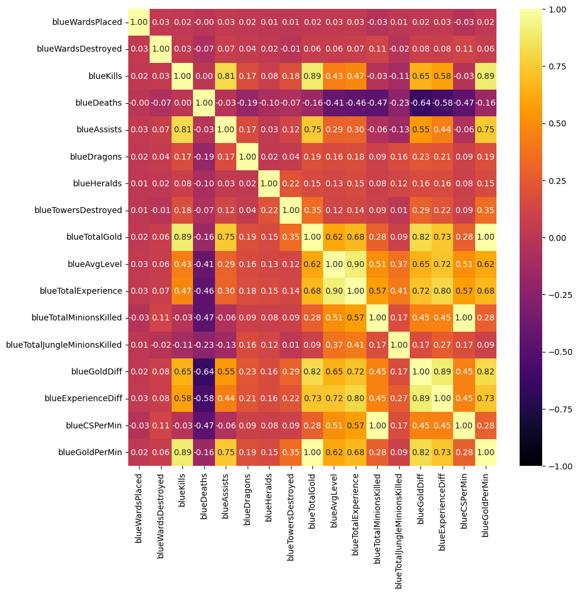

```python
plt.figure(figsize=(10, 10))
#dropping blueWins column because it is our target variable (dependant variable)
sns.heatmap(blueside_data.drop("blueWins",axis=1).corr(), cmap='inferno', annot=True, fmt='.2f', vmin=-1)
```

As you can see from the table above, features that are more closely correlated with one another are lighter (closer to yellow), and the features that are negatively correlated with one another are darker (closer to black) in color, with the smallest correlation being -1.00 and the highest correlation being 1.00. Let's see each distribution in histogram format.

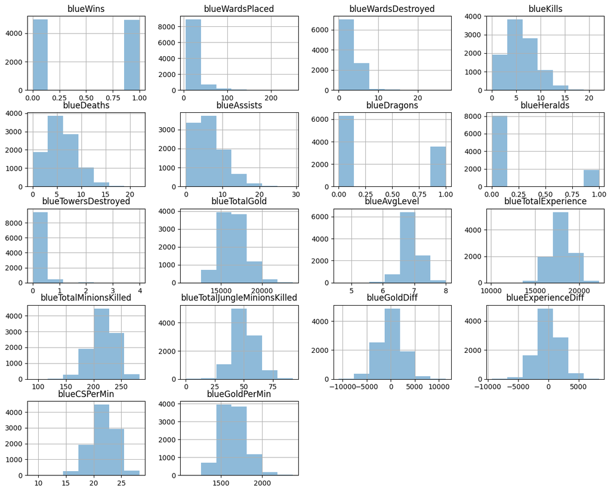

```python
blueside_data.hist(alpha = 0.5, bins=7, figsize=(15,12));
```

Looking at our heatmap, we will ignore the features that have a correlation of 1.00 because those features/variables are either being tested against itself, or the feature they are being tested against is directly correlated with it, meaning they are colinear(e.g. blueGoldPerMin vs blueTotalGold). To clean up our data more, lets remove the columns from the dataframe that have no correlation to blueWins.

```python
#creating a copy of the current dataframe
df_updated = blueside_data.copy()
correlations = df_updated[df_updated.columns[1:]].apply(lambda x: x.corr(df_updated['blueWins']))

column = []
for col in correlations.index:
    if (correlations[col]>0.15 or correlations[col]<-0.15):
        column.append(col)
column
```

```
['blueKills',
 'blueDeaths',
 'blueAssists',
 'blueDragons',
 'blueTotalGold',
 'blueAvgLevel',
 'blueTotalExperience',
 'blueTotalMinionsKilled',
 'blueGoldDiff',
 'blueExperienceDiff',
 'blueCSPerMin',
 'blueGoldPerMin']
```

```python
df_updated = df_updated[column]
df_updated.head(10)
```

|  | blueKills | blueDeaths | blueAssists | blueDragons | blueTotalGold | blueAvgLevel | blueTotalExperience | blueTotalMinionsKilled | blueGoldDiff | blueExperienceDiff | blueCSPerMin | blueGoldPerMin |
| --- | --- | --- | --- | --- | --- | --- | --- | --- | --- | --- | --- | --- |
| 0 | 9 | 6 | 11 | 0 | 17210 | 6.6 | 17039 | 195 | 643 | -8 | 19.5 | 1721.0 |
| 1 | 5 | 5 | 5 | 0 | 14712 | 6.6 | 16265 | 174 | -2908 | -1173 | 17.4 | 1471.2 |
| 2 | 7 | 11 | 4 | 1 | 16113 | 6.4 | 16221 | 186 | -1172 | -1033 | 18.6 | 1611.3 |
| 3 | 4 | 5 | 5 | 0 | 15157 | 7.0 | 17954 | 201 | -1321 | -7 | 20.1 | 1515.7 |
| 4 | 6 | 6 | 6 | 0 | 16400 | 7.0 | 18543 | 210 | -1004 | 230 | 21.0 | 1640.0 |
| 5 | 5 | 3 | 6 | 1 | 15899 | 7.0 | 18161 | 225 | 698 | 101 | 22.5 | 1589.9 |
| 6 | 7 | 6 | 7 | 1 | 16874 | 6.8 | 16967 | 225 | 2411 | 1563 | 22.5 | 1687.4 |
| 7 | 5 | 13 | 3 | 0 | 15305 | 6.4 | 16138 | 209 | -2615 | -800 | 20.9 | 1530.5 |
| 8 | 7 | 7 | 8 | 0 | 16401 | 7.2 | 18527 | 189 | -1979 | -771 | 18.9 | 1640.1 |
| 9 | 4 | 5 | 5 | 1 | 15057 | 6.8 | 16805 | 220 | -1548 | -1574 | 22.0 | 1505.7 |

```python
# train/test split the dataset before normalizing/scaling
from sklearn.model_selection import train_test_split

X = df_updated
y = df['blueWins']
seed = 42
X_train, X_test, y_train, y_test = train_test_split(X, y, test_size=0.3, random_state=seed)

# scale the features
from sklearn.preprocessing import MinMaxScaler

scaler = MinMaxScaler()
scaler.fit(X_train)
X_train = scaler.transform(X_train)
X_test = scaler.transform(X_test)
```

**Decision Tree Classifier**

```python
# fitting the model
from sklearn import tree
from sklearn.model_selection import GridSearchCV
from sklearn.metrics import accuracy_score

decision = tree.DecisionTreeClassifier()

# search the best params
map = {'min_samples_split': [5, 10, 20, 50, 100]},

#grid search w/ cross validation (training model)
clf_tree = GridSearchCV(decision, map, cv=5)
clf_tree.fit(X_train, y_train)

pred_tree = clf_tree.predict(X_test)


# get the accuracy score
dt_acc = accuracy_score(pred_tree, y_test)
print(dt_acc)
print(classification_report(pred_tree, y_test))
```

```
0.6781376518218624
              precision    recall  f1-score   support

           0       0.68      0.68      0.68      1478
           1       0.68      0.68      0.68      1486

    accuracy                           0.68      2964
   macro avg       0.68      0.68      0.68      2964
weighted avg       0.68      0.68      0.68      2964
```

**Logistic Regression**  
Here we will use logistic regression over linear regression because we want to predict probabilities of categorical outcomes, rather than continuous outcomes.

```python
# fit logistic regression model
from sklearn.linear_model import LogisticRegression
lr = LogisticRegression()
lr.fit(X_train, y_train)

# get accuracy score
lr_pred = lr.predict(X_test)
lr_acc = accuracy_score(lr_pred, y_test)
print(f"Accuracy of logistic regression model: {lr_acc:.3f}")
print(f"Classification Report of logistic regression model:")
print(classification_report(lr_pred, y_test))
```

[output not shown]

**Naive Bayes**

```python
# training model
clf_nb = GaussianNB()
clf_nb.fit(X_train, y_train)

nb_pred = clf_nb.predict(X_test)

# get the accuracy score
nb_acc = accuracy_score(nb_pred, y_test)
print(nb_acc)
print(f"Accuracy of naive bayes: {nb_acc:.3f}")
print(f"Classification Report of naive bayes:")
print(classification_report(lr_pred, y_test))
```

[output not shown]

Here is a compact view of all the accuracies in sorted order from least accurate to most accurate.

```python
dictionary = {'Decision Tree': [dt_acc], 'Logistic Regression': [lr_acc],'Naive Bayes': [nb_acc]}
df_acc = pd.DataFrame.from_dict(dictionary, orient='index', columns=['Accuracy Score'])
df_acc = df_acc.sort_values(by='Accuracy Score')
print(df_acc)
```

```
                     Accuracy Score
Decision Tree              0.678138
Naive Bayes                0.717611
Logistic Regression        0.732119
```

Looking at this data, we can see that Logistic Regression has the highest accuracy out of the three. Now lets look at precision and recall for each classifier.

```python
lr_recall = recall_score(lr_pred, y_test, average = None)
lr_precision = precision_score(lr_pred, y_test, average = None)
print('Recall score for logistic regression:{}'.format(lr_recall))
print('Precision score for logistic regression:{}'.format(lr_precision))
```

[output not shown]

**Hypothesis Testing**

Test # 1: Does being on blue side influence winrate of the game?

> Null Hypothesis (H0): The proportion of wins for the blue side is equal to the proportion of wins for the red side. Alternative Hypothesis (H1): The proportion of wins for the blue side is greater than the proportion of wins for the red side.

```python
wins = df['blueWins'].value_counts()
wins
```

[output not shown]

Let's graph the number of blue wins compared to red wins.

```python
blue_wins = df['blueWins']
blue_win_count = blue_wins.sum()
red_win_count = len(blue_wins) - blue_win_count

# Create labels and counts for the plot
labels = ['Blue Wins', 'Red Wins']
counts = [blue_win_count, red_win_count]

# Create the bar plot
plt.figure(figsize=(8, 6))
plt.bar(labels, counts, color=['blue', 'red'])
plt.title('Number of Blue Wins vs Red Wins')
plt.xlabel('Team')
plt.ylabel('Number of Wins')
plt.show()
```

[output not shown]

> We first find the proportion of times that blue wins.

```python
from statsmodels.stats.proportion import proportions_ztest
# Calculate the proportion of wins for the blue side
blue_wins = df['blueWins']
proportion_blue_wins = blue_wins.mean()
print(proportion_blue_wins)
```

[output not shown]

Next, lets find the sample size and the expected proportion for our hypothesis.

> Assuming null hypothesis: Proportion of blue wins is equal to proportion of red wins

> Expected proportion under null hypothesis (if blue and red wins are equal) (.5)

```python
# Calculate the sample size
sample_size = len(blue_wins)

expected_proportion = 0.5
```

Then, we can finally perform the Z-test!

```python
# Perform Z-test
z_statistic, p_value = proportions_ztest(proportion_blue_wins * sample_size, sample_size, expected_proportion)

# Set significance level
alpha = 0.05
```

Finally, compare the p-value to the alpha to see if we can reject the null hypothesis.

```python
if p_value < alpha:
    print("Reject the null hypothesis. There is sufficient evidence to suggest that the blue side wins more games.")
else:
    print("Fail to reject the null hypothesis. There is not enough evidence to conclude that there's a difference in win rates between the blue and red sides.")
```

[output not shown]

Test #2: Does getting first blood (first kill of the game) win you the game?

> Null Hypothesis (H0): A team getting the first blood does not have an effect of the likelihood of a win.

> Alternate Hypothesis (H1): A team getting the first blood has an effect on the likelihood of a win.

```python
contingency_table = pd.crosstab(df['blueFirstBlood'], df['blueWins'])
print(contingency_table)
```

[output not shown]

Here, we can display the proportion of wins relative to whether the first blood is acquired or not.

```python
plt = df.groupby(['blueFirstBlood', 'blueWins']).size().unstack(fill_value=0)
colors = ["blue" if i != 0 else "red" for i in plt]
plt.plot(kind='bar', stacked=True, figsize=(10, 6), title = 'Proportion of Wins vs Losses with 0 First Bloods vs 1 First Blood', xlabel = 'Number of First Bloods', ylabel = 'Number of Games', color = colors)
```

[output not shown]

Now, we can run the chi-square test with a significance level of 0.05.

```python
from scipy.stats import chi2_contingency
chi2_stat, p_val, dof, expected = chi2_contingency(contingency_table)

print("Chi-Squared Statistic:", chi2_stat)
print("P-value:", p_val)
```

[output not shown]

**Insights and Conclusions**

Based off our correlations and our ML analysis, factors to consider in a game include kills, gold, and experience. These features play more of a role when it comes to determining the outcome of a game. Because there is so much variation in a game of League of Legends, there is no one formula fits all where if you just focus on getting "x" amount of kills, or "x" amount of gold/experience difference, then you automatically win the game. Because games are played by actual people, players can make user errors, or may be more skilled in certain areas, which can invalid the results of a game. For example, even though one team may have on average a higher amount of kills at ten minutes into the game, they could still lose the game due to other factors that happen after the first ten minutes. Additionally, because our data was uploaded four years ago, many things may have changed, at least in relation to the professional League of Legends scene. Regardless, we hope that further research can be done on exploring game data, in and outside of this dataset as well. As League of Legends continues to evolve, we want to encourage others to conduct their own analysis of data that they want to explore more in-depth.

```python
!jupyter nbconvert --to html index.ipynb
```

```
[NbConvertApp] Converting notebook index.ipynb to html
[NbConvertApp] Writing 1164477 bytes to index.html
```